# 02b Tree-Based Time Series Models (Random Forest and XGBoost)

> Objective: build leakage-safe tree-based forecasts for monthly credit reporting share, using the same split/evaluation framing as Notebook 02a for direct comparability.

This notebook uses engineered monthly features and evaluates:

- Random Forest multi-output direct forecasting (`h=1..4`)
- XGBoost direct per-horizon forecasting (`h=1..4`, one model per horizon)
- compact hyperparameter grid search for both model families

Horizon scope note:

- `FORECAST_HORIZON = 12` is retained for alignment with 02a framing,
- tree experiments in this notebook are implemented and evaluated on short-lead direct horizons (`h=1..4`) due sample-size and feature-window constraints.

```python
# ============================================================================
# IMPORT STATEMENTS
# ============================================================================
# Core libraries for data prep, feature engineering, modeling, and diagnostics.

import os
import time
import warnings
import numpy as np
import pandas as pd
import matplotlib.pyplot as plt

# Compatibility guard for environments with optional pyarrow/sklearn binary mismatch.
os.environ.setdefault("SKLEARN_ALLOW_INVALID_PYARROW", "1")

SKLEARN_AVAILABLE = True
try:
    from sklearn.preprocessing import StandardScaler
    from sklearn.ensemble import RandomForestRegressor
    from sklearn.multioutput import MultiOutputRegressor
except Exception as e:
    SKLEARN_AVAILABLE = False
    print("scikit-learn import unavailable in this kernel:", e)

# XGBoost imported for upcoming section extension.
import xgboost as xgb

from statsmodels.graphics.tsaplots import plot_acf, plot_pacf

warnings.filterwarnings("ignore")
```

```python
# ============================================================================
# DATA SETUP + SHARED HELPERS (MATCH 03a SPLIT/EVAL STYLE)
# ============================================================================
# Load credit reporting target series and enforce same split logic.

FREQ_ALIAS = "M"
SEASONAL_PERIODS = 12
FORECAST_HORIZON = 12
OUTPUT_TAG = "02b_creditreporting_monthly"

data_path = r"..\data\processed\credit_reporting_timeseries_all.parquet"
df = pd.read_parquet(data_path)

required_cols = {
    "year_month",
    "credit_reporting_count",
    "total_complaints",
    "consumer_consent_yes_count",
    "timely_response_yes_count",
    "consumer_disputed_yes_count",
    "credit_reporting_share",
}
missing = required_cols.difference(df.columns)
if missing:
    raise ValueError(
        f"Missing required columns in credit_reporting_timeseries_all.parquet: {sorted(missing)}"
    )

# Build period-indexed monthly frame using the provided schema only.
ts_df = df[list(required_cols)].copy()
ts_df["period"] = pd.to_datetime(ts_df["year_month"], errors="coerce").dt.to_period(FREQ_ALIAS)
ts_df = ts_df.dropna(subset=["period", "credit_reporting_share"]).sort_values("period")
ts_df = ts_df.groupby("period", as_index=False).first()

# Remove leading rows where share is zero (e.g., early history before product appears).
non_zero_share = ts_df["credit_reporting_share"].astype(float) > 0
if non_zero_share.any():
    first_non_zero_loc = int(non_zero_share.values.argmax())
    ts_df = ts_df.iloc[first_non_zero_loc:].copy()

# Target for tree-based modeling.
series_df = ts_df[["period", "credit_reporting_share"]].rename(columns={"credit_reporting_share": "y"}).set_index("period")
y = series_df["y"].astype(float)

# Use all loaded parquet columns except the requested exclusions and target/date fields.
excluded_feature_cols = {
    "credit_reporting_count",
    "total_complaints",
    "credit_reporting_share",
    "period",
    "year_month",
}
tree_feature_df = ts_df.drop(columns=[c for c in excluded_feature_cols if c in ts_df.columns], errors="ignore")
tree_feature_df.index = series_df.index

n = len(y)
test_size = max(4, n // 5)
val_size = test_size
while n - (val_size + test_size) < 8 and test_size > 2:
    test_size -= 1
    val_size = test_size

train = y.iloc[: n - val_size - test_size].copy()
val = y.iloc[n - val_size - test_size : n - test_size].copy()
test = y.iloc[n - test_size :].copy()

print(f"Source: {data_path}")
print(f"Rows after removing leading zero-share periods: {len(y)}")
print(f"Tree feature columns used: {tree_feature_df.shape[1]}")
print(f"Frequency: {FREQ_ALIAS} | Train={len(train)}, Val={len(val)}, Test={len(test)}")
display(series_df.head())
```

```
Source: ..\data\processed\credit_reporting_timeseries_all.parquet
Rows after removing leading zero-share periods: 159
Tree feature columns used: 3
Frequency: M | Train=97, Val=31, Test=31
```

| period | y |
| --- | --- |
| 2012-10 | 0.053405 |
| 2012-11 | 0.127382 |
| 2012-12 | 0.117185 |
| 2013-01 | 0.093522 |
| 2013-02 | 0.127560 |

```python
# Shared metrics + result/plot helpers for standalone execution
def smape(y_true, y_pred):
    y_true = np.asarray(y_true, dtype=float)
    y_pred = np.asarray(y_pred, dtype=float)
    denom = np.abs(y_true) + np.abs(y_pred)
    ratio = np.where(denom == 0, 0.0, 2.0 * np.abs(y_true - y_pred) / denom)
    return float(100.0 * np.mean(ratio))

def mae(y_true, y_pred):
    return float(np.mean(np.abs(np.asarray(y_true) - np.asarray(y_pred))))

def rmse(y_true, y_pred):
    return float(np.sqrt(np.mean((np.asarray(y_true) - np.asarray(y_pred)) ** 2)))

eval_rows = []

def append_result(model_name, val_pred, test_pred, runtime_sec):
    vp = np.asarray(val_pred, dtype=float)
    tp = np.asarray(test_pred, dtype=float)
    yt_v = y_val_multi.iloc[:, 0].values
    yt_t = y_test_multi.iloc[:, 0].values
    eval_rows.append({
        "Model": model_name,
        "sMAPE_val": smape(yt_v, vp[:, 0] if vp.ndim > 1 else vp),
        "sMAPE_test": smape(yt_t, tp[:, 0] if tp.ndim > 1 else tp),
        "MAE_val": mae(yt_v, vp[:, 0] if vp.ndim > 1 else vp),
        "MAE_test": mae(yt_t, tp[:, 0] if tp.ndim > 1 else tp),
        "RMSE_val": rmse(yt_v, vp[:, 0] if vp.ndim > 1 else vp),
        "RMSE_test": rmse(yt_t, tp[:, 0] if tp.ndim > 1 else tp),
        "runtime_sec": float(runtime_sec),
    })

def plot_section_predictions(title, pred_map):
    fig, axes = plt.subplots(1, 2, figsize=(14, 4), sharey=True)
    for name, (vp, tp) in pred_map.items():
        v = vp[:, 0] if np.asarray(vp).ndim > 1 else np.asarray(vp)
        t = tp[:, 0] if np.asarray(tp).ndim > 1 else np.asarray(tp)
        axes[0].plot(y_val_multi.index.astype(str), y_val_multi.iloc[:, 0].values, label="Actual", color="black")
        axes[0].plot(y_val_multi.index.astype(str), v, label=name)
        axes[1].plot(y_test_multi.index.astype(str), y_test_multi.iloc[:, 0].values, label="Actual", color="black")
        axes[1].plot(y_test_multi.index.astype(str), t, label=name)
    axes[0].set_title(f"{title} - Validation")
    axes[1].set_title(f"{title} - Test")
    for ax in axes:
        ax.tick_params(axis="x", rotation=45)
        ax.grid(True, alpha=0.3)
        ax.legend()
    plt.tight_layout()
    plt.show()
```

## 1. Feature Engineering + Leakage-Safe Pipeline

We use direct multi-horizon forecasting with strict temporal guardrails.

Definitions:

- direct multi-horizon: separate target columns for `t+1` to `t+4` (`y_h1` to `y_h4`)
- leakage: any feature using information not available at prediction time
- exogenous features: non-target variables derived from monthly aggregates (for example consent/timely/disputed counts)

Horizon handling:

- model training/evaluation in this notebook is explicitly on `h=1..4`
- this short-lead horizon is deliberate for tree models under current sample size
- 02a remains the full 12-month baseline reference, and 02b comparisons are interpreted in that context

Leakage controls implemented:

- lag/rolling/EWMA features use past and current information only
- horizon targets are created by forward shifts of the target
- scaling is fit on train only, then applied to validation/test
- split order is strictly time-based

## Implementation Specification (Reviewer Quick Reference)

This table consolidates the concrete implementation choices used in this notebook.

[output not shown]

**Global evaluation protocol:**

- `FORECAST_HORIZON=12` is retained for framing alignment with 02a, but tree model training/evaluation here is explicitly short-lead `h=1..4`,
- comparisons use the same metric family (sMAPE/MAE/RMSE + runtime) and are interpreted with validation-size sensitivity, significance, horizon-step, and bias diagnostics.

```
Feature matrix shape: (143, 43)
Target matrix shape: (143, 4)
Split shapes:
  X_train: (93, 43) | y_train_multi: (93, 4)
  X_val: (4, 43) | y_val_multi: (4, 4)
  X_test: (46, 43) | y_test_multi: (46, 4)
```

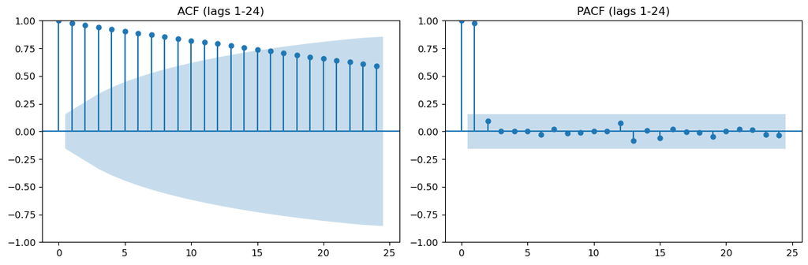

```python
# ============================================================================
# SECTION 1: FEATURE ENGINEERING + LEAKAGE-PROOF PREP
# ============================================================================
# Direct multi-horizon targets and leakage-safe feature matrix construction.

# ---- Multi-horizon direct targets (h=1..4) ----
y1 = y.shift(-1)
y2 = y.shift(-2)
y3 = y.shift(-3)
y4 = y.shift(-4)
y_multi = pd.concat([y1, y2, y3, y4], axis=1)
y_multi.columns = ["y_h1", "y_h2", "y_h3", "y_h4"]

# ---- Feature block on full y (no future leak) ----
feat = pd.DataFrame(index=y.index)

# Lags: y(t-1) ... y(t-12)
for l in range(1, 13):
    feat[f"lag_{l}"] = y.shift(l)

# Rolling windows: local and annual-like
feat["roll_mean_4"] = y.rolling(4).mean()
feat["roll_std_4"] = y.rolling(4).std()
feat["roll_mean_12"] = y.rolling(12).mean()
feat["roll_std_12"] = y.rolling(12).std()

# Seasonal rolling proxy
feat["seasonal_roll_mean_4"] = y.rolling(4).mean()
feat["seasonal_roll_std_4"] = y.rolling(4).std()

# EWMA with alpha=0.3
feat["ewm_a03"] = y.ewm(alpha=0.3, adjust=False).mean()

# Calendar / trend features
feat["cum_q"] = np.arange(len(y), dtype=float)
feat["year_since_2012"] = (y.index.year - 2012).astype(float)
feat["days_since_start"] = (y.index.to_timestamp(how="end") - y.index[0].to_timestamp(how="end")).days.astype(float)

# Month dummies (for monthly frequency)
m_dummies = pd.get_dummies(y.index.month, prefix="M", drop_first=False).astype(int)
m_dummies.index = y.index
feat = pd.concat([feat, m_dummies], axis=1)

# Fourier terms for monthly seasonality, k=1,2
for k in [1, 2]:
    feat[f"sin_k{k}"] = np.sin(2 * np.pi * k * feat["cum_q"] / 12.0)
    feat[f"cos_k{k}"] = np.cos(2 * np.pi * k * feat["cum_q"] / 12.0)

# Linear trend residual feature
coef = np.polyfit(feat["cum_q"].values, y.values, 1)
trend_line = coef[0] * feat["cum_q"].values + coef[1]
feat["trend_linear"] = trend_line
feat["trend_resid"] = y.values - trend_line

# Add all retained parquet features (except excluded cols handled in setup cell).
if "tree_feature_df" in globals() and tree_feature_df is not None and not tree_feature_df.empty:
    exog = tree_feature_df.reindex(y.index).copy()
    exog = pd.get_dummies(exog, drop_first=False, dtype=int)
    exog = exog.apply(pd.to_numeric, errors="coerce")
    feat = pd.concat([feat, exog], axis=1)

# Align X and y_multi, dropping rows with any NA from lag/rolling/target shifts
frame = pd.concat([feat, y_multi], axis=1).dropna().copy()

X = frame[feat.columns]
Y = frame[y_multi.columns]

# Required split alignment using train length from setup split
split_train_end = len(train) - 4
split_val_end = len(train)

X_train = X.iloc[:split_train_end].copy()
X_val = X.iloc[split_train_end:split_val_end].copy()
X_test = X.iloc[split_val_end:].copy()

y_train_multi = Y.iloc[:split_train_end].copy()
y_val_multi = Y.iloc[split_train_end:split_val_end].copy()
y_test_multi = Y.iloc[split_val_end:].copy()

# Scale on train only to avoid leakage; trees are scale-invariant, but kept for consistency.
sk_ok = globals().get("SKLEARN_AVAILABLE", False)
if sk_ok:
    scaler = StandardScaler()
    X_train_scaled = pd.DataFrame(scaler.fit_transform(X_train), index=X_train.index, columns=X_train.columns)
    X_val_scaled = pd.DataFrame(scaler.transform(X_val), index=X_val.index, columns=X_val.columns)
    X_test_scaled = pd.DataFrame(scaler.transform(X_test), index=X_test.index, columns=X_test.columns)
else:
    X_train_scaled = X_train.copy()
    X_val_scaled = X_val.copy()
    X_test_scaled = X_test.copy()

print("Feature matrix shape:", X.shape)
print("Target matrix shape:", Y.shape)
print("Split shapes:")
print("  X_train:", X_train_scaled.shape, "| y_train_multi:", y_train_multi.shape)
print("  X_val:", X_val_scaled.shape, "| y_val_multi:", y_val_multi.shape)
print("  X_test:", X_test_scaled.shape, "| y_test_multi:", y_test_multi.shape)

# ACF/PACF diagnostics up to lag 24 for monthly structure check
from statsmodels.graphics.tsaplots import plot_acf, plot_pacf

fig, axes = plt.subplots(1, 2, figsize=(12, 4))
plot_acf(y.values, lags=24, ax=axes[0])
axes[0].set_title("ACF (lags 1-24)")
plot_pacf(y.values, lags=24, ax=axes[1], method="ywm")
axes[1].set_title("PACF (lags 1-24)")
plt.tight_layout()
plt.show()
```

## 2. Random Forest (Multi-Horizon Direct)

We fit `MultiOutputRegressor(RandomForestRegressor)` to predict `y_h1` to `y_h4` simultaneously.

Forecast-design clarification:

- this is a **direct multi-horizon** setup, not recursive forecasting,
- `MultiOutputRegressor` trains one separate RF estimator per target column (`y_h1`, `y_h2`, `y_h3`, `y_h4`) using the same feature matrix,
- horizon `h+2` to `h+4` predictions do **not** consume earlier predicted values as inputs.

Evaluation outputs include:

- macro summary metrics (validation and test)
- per-horizon metric table (`h=1` to `h=4`)
- horizon-1 trajectory plot (actual vs predicted)
- feature-importance chart from the `h=1` estimator

Current run context:

- RF performs strongly on validation but underpredicts the higher test-period level, which increases test error relative to statistical baselines.

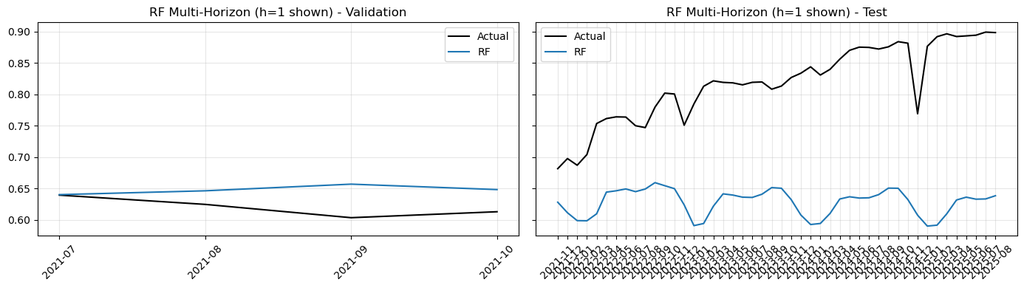

```
Model Summary
```

|  | Model | sMAPE_val | sMAPE_test | MAE_val | MAE_test | RMSE_val | RMSE_test | runtime_sec |
| --- | --- | --- | --- | --- | --- | --- | --- | --- |
| 0 | RF-Multi | 4.407 | 26.079 | 0.028 | 0.191 | 0.034 | 0.2 | 4.178 |

```
Per-Horizon Metrics
```

|  | Horizon | sMAPE_val | sMAPE_test | MAE_val | MAE_test | RMSE_val | RMSE_test |
| --- | --- | --- | --- | --- | --- | --- | --- |
| 0 | h=1 | 4.407 | 26.079 | 0.028 | 0.191 | 0.034 | 0.200 |
| 1 | h=2 | 6.872 | 25.505 | 0.044 | 0.187 | 0.049 | 0.197 |
| 2 | h=3 | 6.213 | 27.087 | 0.040 | 0.199 | 0.046 | 0.207 |
| 3 | h=4 | 8.131 | 27.674 | 0.053 | 0.204 | 0.058 | 0.210 |

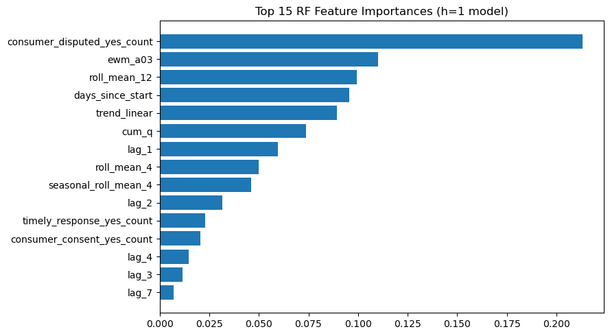

```
Random Forest multi-horizon evaluation complete.
```

```python
# ============================================================================
# SECTION 2: RANDOM FOREST (MULTI-OUTPUT, DIRECT HORIZONS)
# ============================================================================

t0 = time.perf_counter()
rf = MultiOutputRegressor(
    RandomForestRegressor(
        n_estimators=500,
        max_depth=6,
        random_state=42,
        n_jobs=-1
    )
)
rf.fit(X_train_scaled, y_train_multi)
runtime = time.perf_counter() - t0

val_pred = rf.predict(X_val_scaled)
test_pred = rf.predict(X_test_scaled)

append_result("RF-Multi", val_pred, test_pred, runtime)
plot_section_predictions("RF Multi-Horizon (h=1 shown)", {"RF": (val_pred, test_pred)})

# Per-horizon sMAPE/MAE/RMSE table
h_rows = []
for h in range(4):
    h_rows.append({
        "Horizon": f"h={h+1}",
        "sMAPE_val": smape(y_val_multi.iloc[:, h].values, val_pred[:, h]),
        "sMAPE_test": smape(y_test_multi.iloc[:, h].values, test_pred[:, h]),
        "MAE_val": mae(y_val_multi.iloc[:, h].values, val_pred[:, h]),
        "MAE_test": mae(y_test_multi.iloc[:, h].values, test_pred[:, h]),
        "RMSE_val": rmse(y_val_multi.iloc[:, h].values, val_pred[:, h]),
        "RMSE_test": rmse(y_test_multi.iloc[:, h].values, test_pred[:, h]),
    })

horizon_metrics = pd.DataFrame(h_rows)
for c in ["sMAPE_val", "sMAPE_test", "MAE_val", "MAE_test", "RMSE_val", "RMSE_test"]:
    horizon_metrics[c] = horizon_metrics[c].round(3)

results = pd.DataFrame(eval_rows).copy()
for c in ["sMAPE_val", "sMAPE_test", "MAE_val", "MAE_test", "RMSE_val", "RMSE_test", "runtime_sec"]:
    results[c] = results[c].round(3)

print("Model Summary")
display(results)
print("Per-Horizon Metrics")
display(horizon_metrics)

# Feature importance (h=1 estimator) for quick interpretability
rf_h1 = rf.estimators_[0]
fi = pd.DataFrame({
    "Feature": X_train_scaled.columns,
    "Importance": rf_h1.feature_importances_
}).sort_values("Importance", ascending=False).head(15)

fig, ax = plt.subplots(figsize=(9, 5))
ax.barh(fi["Feature"][::-1], fi["Importance"][::-1])
ax.set_title("Top 15 RF Feature Importances (h=1 model)")
plt.tight_layout()
plt.show()

print("Random Forest multi-horizon evaluation complete.")
```

## Notes

- Notebook 02b is benchmarked against rebuilt 02a-style baselines on the same split for apples-to-apples comparison.
- Target is monthly `credit_reporting_share` after removing leading zero-share periods.
- Tree features combine time-series transforms with retained monthly aggregate covariates.
- Latest run indicates trees fit validation well but trail the best statistical baseline on the test window.

## 3. XGBoost (Direct Per-Horizon Models)

This section fits one native XGBoost model per horizon and stacks predictions into a multi-horizon output.

Forecast-design clarification:

- this is also a **direct** strategy (one model per horizon), not recursive roll-forward,
- four boosters are fit independently for `y_h1` to `y_h4`,
- each horizon model uses observed historical features only; later-horizon predictions are not generated from earlier forecasted targets.

Why this design:

- avoids sklearn dependency for multi-output wrapping
- keeps full control over booster parameters
- maintains the same evaluation interface as the RF section

Current run context:

- XGBoost is faster than RF in runtime, but test errors are higher than RF and substantially higher than the best rebuilt 02a baseline.

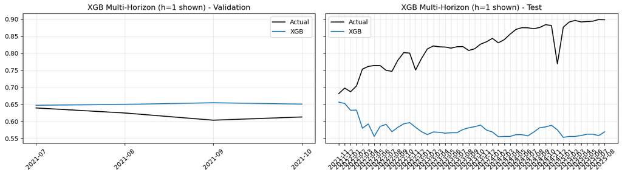

```
XGB Per-Horizon Metrics
```

|  | Horizon | sMAPE_val | sMAPE_test | MAE_val | MAE_test | RMSE_val | RMSE_test |
| --- | --- | --- | --- | --- | --- | --- | --- |
| 0 | h=1 | 4.827 | 34.287 | 0.031 | 0.241 | 0.034 | 0.254 |
| 1 | h=2 | 6.473 | 32.948 | 0.042 | 0.234 | 0.047 | 0.244 |
| 2 | h=3 | 5.943 | 29.039 | 0.039 | 0.211 | 0.043 | 0.220 |
| 3 | h=4 | 4.503 | 28.553 | 0.030 | 0.209 | 0.030 | 0.216 |

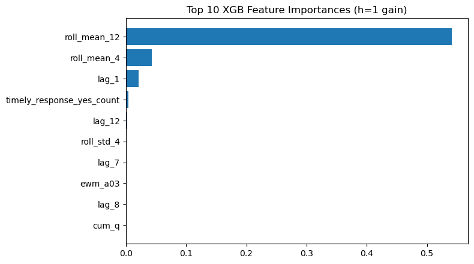

```
XGBoost multi-output evaluation complete.
```

```python
# ============================================================================
# SECTION 3: XGBOOST (SKLEARN-FREE NATIVE, DIRECT MULTI-HORIZON)
# ============================================================================
import xgboost as xgb

def fit_xgb_by_horizon(X_df, Y_df, params, num_boost_round):
    models = {}
    for col in Y_df.columns:
        dtrain = xgb.DMatrix(X_df.values, label=Y_df[col].values, feature_names=list(X_df.columns))
        models[col] = xgb.train(params, dtrain, num_boost_round=num_boost_round, verbose_eval=False)
    return models

def predict_xgb_by_horizon(models, X_df, y_cols):
    dtest = xgb.DMatrix(X_df.values, feature_names=list(X_df.columns))
    preds = []
    for col in y_cols:
        preds.append(models[col].predict(dtest))
    return np.column_stack(preds)

xgb_params = {
    "eta": 0.1,
    "max_depth": 6,
    "subsample": 1.0,
    "colsample_bytree": 1.0,
    "objective": "reg:squarederror",
    "seed": 42,
}

num_boost_round = 200

t0 = time.perf_counter()
xgb_models = fit_xgb_by_horizon(X_train, y_train_multi, xgb_params, num_boost_round)
runtime = time.perf_counter() - t0

xgb_val_pred = predict_xgb_by_horizon(xgb_models, X_val, y_train_multi.columns)
xgb_test_pred = predict_xgb_by_horizon(xgb_models, X_test, y_train_multi.columns)

append_result("XGB-Multi", xgb_val_pred, xgb_test_pred, runtime)
plot_section_predictions("XGB Multi-Horizon (h=1 shown)", {"XGB": (xgb_val_pred, xgb_test_pred)})

# Per-horizon metric table
xgb_h_rows = []
for h in range(4):
    xgb_h_rows.append({
        "Horizon": f"h={h+1}",
        "sMAPE_val": smape(y_val_multi.iloc[:, h].values, xgb_val_pred[:, h]),
        "sMAPE_test": smape(y_test_multi.iloc[:, h].values, xgb_test_pred[:, h]),
        "MAE_val": mae(y_val_multi.iloc[:, h].values, xgb_val_pred[:, h]),
        "MAE_test": mae(y_test_multi.iloc[:, h].values, xgb_test_pred[:, h]),
        "RMSE_val": rmse(y_val_multi.iloc[:, h].values, xgb_val_pred[:, h]),
        "RMSE_test": rmse(y_test_multi.iloc[:, h].values, xgb_test_pred[:, h]),
    })
xgb_horizon_metrics = pd.DataFrame(xgb_h_rows)
for c in ["sMAPE_val", "sMAPE_test", "MAE_val", "MAE_test", "RMSE_val", "RMSE_test"]:
    xgb_horizon_metrics[c] = xgb_horizon_metrics[c].round(3)

print("XGB Per-Horizon Metrics")
display(xgb_horizon_metrics)

# Top-10 feature importance from h=1 model
h1_model = xgb_models["y_h1"]
score_map = h1_model.get_score(importance_type="gain")
imp_df = pd.DataFrame({
    "Feature": list(X_train.columns),
    "Importance": [score_map.get(f, 0.0) for f in X_train.columns]
}).sort_values("Importance", ascending=False).head(10)

fig, ax = plt.subplots(figsize=(8, 4.5))
ax.barh(imp_df["Feature"][::-1], imp_df["Importance"][::-1])
ax.set_title("Top 10 XGB Feature Importances (h=1 gain)")
plt.tight_layout()
plt.show()

# Keep one-step (h=1) tree scores for baseline comparison section.
if "tree_h1_rows" not in globals():
    tree_h1_rows = []

tree_h1_rows.append({
    "Model": "XGB-Multi (h=1)",
    "sMAPE_val": smape(y_val_multi["y_h1"].values, xgb_val_pred[:, 0]),
    "MAE_val": mae(y_val_multi["y_h1"].values, xgb_val_pred[:, 0]),
    "RMSE_val": rmse(y_val_multi["y_h1"].values, xgb_val_pred[:, 0]),
    "sMAPE_test": smape(y_test_multi["y_h1"].values, xgb_test_pred[:, 0]),
    "MAE_test": mae(y_test_multi["y_h1"].values, xgb_test_pred[:, 0]),
    "RMSE_test": rmse(y_test_multi["y_h1"].values, xgb_test_pred[:, 0]),
    "runtime_sec": runtime
})

print("XGBoost multi-output evaluation complete.")
```

## 4. Hyperparameter Grid Search

We run a compact search using validation macro-sMAPE for model selection, then evaluate selected configurations on test.

Validation-reliability context:

- the validation slice is intentionally small because the total usable monthly sample is limited,
- with small validation windows, hyperparameter rankings can be noisy and over-react to a few months,
- therefore grid-search results are treated as **provisional tuning guidance**, while final claims rely on test metrics and cross-section consistency.

Mitigations used in this notebook:

- compact grids (to reduce overfitting to one small validation slice),
- macro-horizon validation scoring instead of single-horizon tuning,
- explicit test-window comparison table against 02a baselines,
- follow-up sensitivity check (next cell) to show whether multiple configs are near-tied on validation.

Interpretation guide:

- lower validation macro-sMAPE indicates better multi-horizon fit on the validation slice
- final model ranking should still rely on the test metrics in the comparison table

Latest selected configurations from the current run:

```python
# ============================================================================
# SECTION 4: HYPERPARAMETER GRID SEARCH
# ============================================================================
import xgboost as xgb

def macro_smape_multi(y_true_df, y_pred_arr):
    vals = []
    for h in range(y_pred_arr.shape[1]):
        vals.append(smape(y_true_df.iloc[:, h].values, y_pred_arr[:, h]))
    return float(np.mean(vals))

def fit_xgb_by_horizon(X_df, Y_df, params, num_boost_round):
    models = {}
    for col in Y_df.columns:
        dtrain = xgb.DMatrix(X_df.values, label=Y_df[col].values, feature_names=list(X_df.columns))
        models[col] = xgb.train(params, dtrain, num_boost_round=num_boost_round, verbose_eval=False)
    return models

def predict_xgb_by_horizon(models, X_df, y_cols):
    dtest = xgb.DMatrix(X_df.values, feature_names=list(X_df.columns))
    return np.column_stack([models[col].predict(dtest) for col in y_cols])

grid_rows = []

# ---- RF grid (if sklearn available) ----
sk_ok = globals().get("SKLEARN_AVAILABLE", False)
if sk_ok:
    rf_grid = {
        "n_estimators": [300, 500],
        "max_depth": [4, 6, 8],
        "min_samples_leaf": [1, 2]
    }

    best_rf_cfg = None
    best_rf_val = np.inf

    for n_est in rf_grid["n_estimators"]:
        for m_depth in rf_grid["max_depth"]:
            for m_leaf in rf_grid["min_samples_leaf"]:
                model = MultiOutputRegressor(
                    RandomForestRegressor(
                        n_estimators=n_est,
                        max_depth=m_depth,
                        min_samples_leaf=m_leaf,
                        random_state=42,
                        n_jobs=-1
                    )
                )
                model.fit(X_train_scaled, y_train_multi)
                pred_val = model.predict(X_val_scaled)
                score_val = macro_smape_multi(y_val_multi, pred_val)

                grid_rows.append({
                    "ModelFamily": "RF",
                    "Params": f"n={n_est},depth={m_depth},leaf={m_leaf}",
                    "Val_sMAPE_macro": score_val
                })

                if score_val < best_rf_val:
                    best_rf_val = score_val
                    best_rf_cfg = (n_est, m_depth, m_leaf)

    t0 = time.perf_counter()
    rf_best = MultiOutputRegressor(
        RandomForestRegressor(
            n_estimators=best_rf_cfg[0],
            max_depth=best_rf_cfg[1],
            min_samples_leaf=best_rf_cfg[2],
            random_state=42,
            n_jobs=-1
        )
    )
    rf_best.fit(X_train_scaled, y_train_multi)
    rf_runtime = time.perf_counter() - t0

    rf_val_pred = rf_best.predict(X_val_scaled)
    rf_test_pred = rf_best.predict(X_test_scaled)
    append_result("RF-GridBest", rf_val_pred, rf_test_pred, rf_runtime)

    if "tree_h1_rows" not in globals():
        tree_h1_rows = []
    tree_h1_rows.append({
        "Model": "RF-GridBest (h=1)",
        "sMAPE_val": smape(y_val_multi["y_h1"].values, rf_val_pred[:, 0]),
        "MAE_val": mae(y_val_multi["y_h1"].values, rf_val_pred[:, 0]),
        "RMSE_val": rmse(y_val_multi["y_h1"].values, rf_val_pred[:, 0]),
        "sMAPE_test": smape(y_test_multi["y_h1"].values, rf_test_pred[:, 0]),
        "MAE_test": mae(y_test_multi["y_h1"].values, rf_test_pred[:, 0]),
        "RMSE_test": rmse(y_test_multi["y_h1"].values, rf_test_pred[:, 0]),
        "runtime_sec": rf_runtime
    })

    print("Best RF config:", best_rf_cfg, "| val macro sMAPE:", round(best_rf_val, 3))
else:
    print("RF grid search skipped: scikit-learn unavailable in current kernel.")

# ---- XGB grid (native, sklearn-free) ----
xgb_grid = {
    "num_boost_round": [100, 200, 300],
    "eta": [0.05, 0.1],
    "max_depth": [4, 6]
}

best_xgb_cfg = None
best_xgb_val = np.inf

for n_round in xgb_grid["num_boost_round"]:
    for eta in xgb_grid["eta"]:
        for md in xgb_grid["max_depth"]:
            params = {
                "eta": eta,
                "max_depth": md,
                "subsample": 1.0,
                "colsample_bytree": 1.0,
                "objective": "reg:squarederror",
                "seed": 42,
            }
            models = fit_xgb_by_horizon(X_train, y_train_multi, params, n_round)
            pred_val = predict_xgb_by_horizon(models, X_val, y_train_multi.columns)
            score_val = macro_smape_multi(y_val_multi, pred_val)

            grid_rows.append({
                "ModelFamily": "XGB",
                "Params": f"round={n_round},eta={eta},depth={md}",
                "Val_sMAPE_macro": score_val
            })

            if score_val < best_xgb_val:
                best_xgb_val = score_val
                best_xgb_cfg = (n_round, eta, md)

best_params = {
    "eta": best_xgb_cfg[1],
    "max_depth": best_xgb_cfg[2],
    "subsample": 1.0,
    "colsample_bytree": 1.0,
    "objective": "reg:squarederror",
    "seed": 42,
}

t0 = time.perf_counter()
xgb_best_models = fit_xgb_by_horizon(X_train, y_train_multi, best_params, best_xgb_cfg[0])
xgb_runtime = time.perf_counter() - t0

xgb_val_best = predict_xgb_by_horizon(xgb_best_models, X_val, y_train_multi.columns)
xgb_test_best = predict_xgb_by_horizon(xgb_best_models, X_test, y_train_multi.columns)
append_result("XGB-GridBest", xgb_val_best, xgb_test_best, xgb_runtime)

if "tree_h1_rows" not in globals():
    tree_h1_rows = []
tree_h1_rows.append({
    "Model": "XGB-GridBest (h=1)",
    "sMAPE_val": smape(y_val_multi["y_h1"].values, xgb_val_best[:, 0]),
    "MAE_val": mae(y_val_multi["y_h1"].values, xgb_val_best[:, 0]),
    "RMSE_val": rmse(y_val_multi["y_h1"].values, xgb_val_best[:, 0]),
    "sMAPE_test": smape(y_test_multi["y_h1"].values, xgb_test_best[:, 0]),
    "MAE_test": mae(y_test_multi["y_h1"].values, xgb_test_best[:, 0]),
    "RMSE_test": rmse(y_test_multi["y_h1"].values, xgb_test_best[:, 0]),
    "runtime_sec": xgb_runtime
})

print("Best XGB config:", best_xgb_cfg, "| val macro sMAPE:", round(best_xgb_val, 3))

grid_results = pd.DataFrame(grid_rows).sort_values(["ModelFamily", "Val_sMAPE_macro"]).reset_index(drop=True)
grid_results["Val_sMAPE_macro"] = grid_results["Val_sMAPE_macro"].round(3)
display(grid_results.head(20))

tree_results = pd.DataFrame(eval_rows).copy()
for c in ["sMAPE_val", "MAE_val", "RMSE_val", "sMAPE_test", "MAE_test", "RMSE_test", "runtime_sec"]:
    tree_results[c] = tree_results[c].round(3)

print("Tree Model Summary (macro across h=1..4):")
display(tree_results)
```

```
Best RF config: (300, 8, 1) | val macro sMAPE: 6.268
Best XGB config: (100, 0.05, 6) | val macro sMAPE: 4.98
```

|  | ModelFamily | Params | Val_sMAPE_macro |
| --- | --- | --- | --- |
| 0 | RF | n=300,depth=8,leaf=1 | 6.268 |
| 1 | RF | n=300,depth=6,leaf=1 | 6.313 |
| 2 | RF | n=500,depth=8,leaf=1 | 6.353 |
| 3 | RF | n=500,depth=6,leaf=1 | 6.363 |
| 4 | RF | n=300,depth=4,leaf=1 | 6.363 |
| 5 | RF | n=500,depth=4,leaf=1 | 6.412 |
| 6 | RF | n=300,depth=6,leaf=2 | 6.487 |
| 7 | RF | n=500,depth=8,leaf=2 | 6.501 |
| 8 | RF | n=300,depth=8,leaf=2 | 6.507 |
| 9 | RF | n=500,depth=6,leaf=2 | 6.508 |
| 10 | RF | n=300,depth=4,leaf=2 | 6.518 |
| 11 | RF | n=500,depth=4,leaf=2 | 6.562 |
| 12 | XGB | round=100,eta=0.05,depth=6 | 4.980 |
| 13 | XGB | round=100,eta=0.05,depth=4 | 5.154 |
| 14 | XGB | round=200,eta=0.05,depth=6 | 5.162 |
| 15 | XGB | round=300,eta=0.05,depth=6 | 5.162 |
| 16 | XGB | round=100,eta=0.1,depth=4 | 5.245 |
| 17 | XGB | round=200,eta=0.1,depth=4 | 5.257 |
| 18 | XGB | round=300,eta=0.1,depth=4 | 5.257 |
| 19 | XGB | round=200,eta=0.05,depth=4 | 5.347 |

```
Tree Model Summary (macro across h=1..4):
```

|  | Model | sMAPE_val | sMAPE_test | MAE_val | MAE_test | RMSE_val | RMSE_test | runtime_sec |
| --- | --- | --- | --- | --- | --- | --- | --- | --- |
| 0 | RF-GridBest | 4.303 | 26.330 | 0.027 | 0.192 | 0.033 | 0.202 | 1.679 |
| 1 | XGB-GridBest | 3.346 | 34.753 | 0.021 | 0.244 | 0.026 | 0.257 | 0.581 |

### 4.1. Validation-Size Sensitivity Check

Because tuning relies on a limited validation block, this check quantifies how sharply (or weakly) the selected configuration is separated from alternatives.

Read this as follows:

- if many configurations are within a small margin of the best validation score, selection uncertainty is high,
- if only one configuration is clearly separated, tuning is more stable,
- high uncertainty means model-comparison claims should emphasize test performance and robustness over tiny validation differences.

```python
# ============================================================================
# SECTION 4.1: VALIDATION-SIZE SENSITIVITY DIAGNOSTICS
# ============================================================================

if 'grid_results' not in globals() or not isinstance(grid_results, pd.DataFrame) or grid_results.empty:
    print('grid_results not available. Run Section 4 first.')
else:
    diag_rows = []
    margin_pct = 2.0  # near-tie threshold around best validation score

    for fam in sorted(grid_results['ModelFamily'].dropna().unique()):
        g = grid_results[grid_results['ModelFamily'] == fam].copy()
        g = g.sort_values('Val_sMAPE_macro').reset_index(drop=True)

        best = float(g.iloc[0]['Val_sMAPE_macro'])
        second = float(g.iloc[1]['Val_sMAPE_macro']) if len(g) > 1 else np.nan
        rel_gap_second = ((second - best) / max(best, 1e-12)) * 100.0 if np.isfinite(second) else np.nan

        near_ties = int((g['Val_sMAPE_macro'] <= best * (1.0 + margin_pct / 100.0)).sum())

        diag_rows.append({
            'ModelFamily': fam,
            'NumGridConfigs': int(len(g)),
            'Best_Val_sMAPE_macro': best,
            'SecondBest_Val_sMAPE_macro': second,
            'Second_vs_Best_Gap_%': rel_gap_second,
            'Configs_within_2pct_of_Best': near_ties,
            'SelectionStabilityFlag': 'Low (near-tied)' if near_ties >= 3 else 'Higher (more separated)',
        })

    tuning_stability = pd.DataFrame(diag_rows)
    for c in ['Best_Val_sMAPE_macro', 'SecondBest_Val_sMAPE_macro', 'Second_vs_Best_Gap_%']:
        tuning_stability[c] = tuning_stability[c].round(3)

    print('Validation-size sensitivity diagnostics:')
    display(tuning_stability)

    # concise narrative line
    unstable = tuning_stability[tuning_stability['SelectionStabilityFlag'].str.contains('Low', na=False)]
    if len(unstable) > 0:
        fams = ', '.join(unstable['ModelFamily'].tolist())
        print(f'Interpretation: tuning for {fams} appears sensitive on a small validation slice; prioritize test-window evidence for final comparisons.')
    else:
        print('Interpretation: best-vs-runner validation separation is reasonably clear in this run, though test metrics remain the final arbiter.')
```

```
Validation-size sensitivity diagnostics:
```

|  | ModelFamily | NumGridConfigs | Best_Val_sMAPE_macro | SecondBest_Val_sMAPE_macro | Second_vs_Best_Gap_% | Configs_within_2pct_of_Best | SelectionStabilityFlag |
| --- | --- | --- | --- | --- | --- | --- | --- |
| 0 | RF | 12 | 6.268 | 6.313 | 0.718 | 5 | Low (near-tied) |
| 1 | XGB | 12 | 4.980 | 5.154 | 3.494 | 1 | Higher (more separated) |

```
Interpretation: tuning for RF appears sensitive on a small validation slice; prioritize test-window evidence for final comparisons.
```

## 5. Comparison Table vs 02a Baselines

This section rebuilds 02a-style baseline models on the same split and compares them against tree `h=1` results.

Metric definitions:

- sMAPE: scale-independent percentage error, robust to level differences
- MAE: average absolute error in target units
- RMSE: penalizes larger misses more than MAE

Use this table as the primary model-selection artifact for this notebook.

```python
# ============================================================================
# SECTION 5: COMPARISON TABLE VS 02a BASELINES (FAST PATH)
# ============================================================================
# This section avoids refitting expensive baseline models.
# It reuses 02a Sec. 8 artifact results or cached CSV artifacts.

export_dir = "../reports/2026-03-26/tables"
artifact_dir = "../reports/artifacts"
baseline_artifact = f"{artifact_dir}/02a_creditreporting_monthly_baseline_results.csv"
baseline_cache = f"{export_dir}/02b_creditreporting_monthly_rebuilt_02a_baselines.csv"
tree_h1_cache = f"{export_dir}/02b_creditreporting_monthly_tree_h1_summary.csv"

# Initialize explicitly so the symbol is always defined in this notebook scope.
baseline_results = pd.DataFrame()
baseline_results_fast = pd.DataFrame()
baseline_source = ""

# ---- Load rebuilt 02a baselines quickly (artifact-first) ----
if os.path.exists(baseline_artifact):
    baseline_results_fast = pd.read_csv(baseline_artifact)
    baseline_source = baseline_artifact
elif "baseline_results" in globals() and isinstance(baseline_results, pd.DataFrame) and not baseline_results.empty:
    baseline_results_fast = baseline_results.copy()
    baseline_source = "in-memory baseline_results"
elif os.path.exists(baseline_cache):
    baseline_results_fast = pd.read_csv(baseline_cache)
    baseline_source = baseline_cache
else:
    raise RuntimeError(
        "No baseline artifact/cache found. Run 02a Sec. 8 once to export results, then rerun this section. "
        f"Expected artifact: {baseline_artifact} or cache: {baseline_cache}"
    )

# Backward-compatibility alias for downstream cells that still reference baseline_results.
baseline_results = baseline_results_fast.copy()

# Ensure consistent family label
baseline_results_fast["Family"] = "02a-baseline"

# ---- Load tree h=1 summary quickly ----
if "tree_h1_rows" in globals() and len(tree_h1_rows) > 0:
    tree_h1_df = pd.DataFrame(tree_h1_rows).copy()
elif os.path.exists(tree_h1_cache):
    tree_h1_df = pd.read_csv(tree_h1_cache)
else:
    # Fallback from macro summary if tree_h1 cache is unavailable
    if "tree_results" in globals() and isinstance(tree_results, pd.DataFrame) and not tree_results.empty:
        tree_h1_df = tree_results.copy()
    else:
        tree_h1_df = pd.DataFrame(columns=["Model", "sMAPE_val", "MAE_val", "RMSE_val", "sMAPE_test", "MAE_test", "RMSE_test", "runtime_sec"])

if not tree_h1_df.empty:
    tree_h1_df["Family"] = "tree-h1"

# ---- Build comparison table ----
comparison = pd.concat([baseline_results_fast, tree_h1_df], ignore_index=True, sort=False)
comparison = comparison.sort_values(["sMAPE_test", "MAE_test", "runtime_sec"]).reset_index(drop=True)

for c in ["sMAPE_val", "MAE_val", "RMSE_val", "sMAPE_test", "MAE_test", "RMSE_test", "runtime_sec"]:
    comparison[c] = pd.to_numeric(comparison[c], errors="coerce").round(3)

print(f"Loaded baseline source: {baseline_source}")
print("Comparison: Tree Models vs 02a Baselines (fast cache mode)")
display(comparison)
```

```
Loaded baseline source: ../reports/artifacts/02a_creditreporting_monthly_baseline_results.csv
Comparison: Tree Models vs 02a Baselines (fast cache mode)
```

|  | Model | sMAPE_val | MAE_val | RMSE_val | sMAPE_test | MAE_test | RMSE_test | runtime_sec | Notes | Family |
| --- | --- | --- | --- | --- | --- | --- | --- | --- | --- | --- |
| 0 | Theta | 8.203 | 0.056 | 0.064 | 2.011 | 0.017 | 0.026 | 0.031 | Strong trend-seasonality balance | 02a-baseline |
| 1 | Naive | 12.311 | 0.083 | 0.102 | 5.727 | 0.048 | 0.058 | 0.000 | Too biased | 02a-baseline |
| 2 | ARIMA(1, 1, 0) | 11.998 | 0.081 | 0.100 | 5.990 | 0.051 | 0.060 | 4.705 | No explicit seasonality (auto-selected orders) | 02a-baseline |
| 3 | SARIMA(1, 1, 0)x(0,0,1,12) | 12.311 | 0.083 | 0.103 | 6.016 | 0.051 | 0.060 | 7.122 | Strong seasonal baseline (auto-selected orders) | 02a-baseline |
| 4 | ETS SES | 12.142 | 0.082 | 0.101 | 6.075 | 0.051 | 0.061 | 0.033 | May underfit trend | 02a-baseline |
| 5 | FFT | 8.356 | 0.055 | 0.069 | 6.160 | 0.055 | 0.063 | 0.004 | Seasonal frequency focus | 02a-baseline |
| 6 | ETS Holt-Winters | 6.522 | 0.044 | 0.057 | 7.311 | 0.066 | 0.074 | 0.127 | Can over/under-smooth peaks | 02a-baseline |
| 7 | Moving Average | 13.408 | 0.090 | 0.109 | 8.697 | 0.072 | 0.080 | 0.000 | Too flat | 02a-baseline |
| 8 | Seasonal Naive | 23.195 | 0.146 | 0.164 | 10.594 | 0.087 | 0.095 | 0.000 | Misses trend/regime shifts | 02a-baseline |
| 9 | RF-GridBest (h=1) | 4.303 | 0.027 | 0.033 | 26.330 | 0.192 | 0.202 | 1.679 | NaN | tree-h1 |
| 10 | XGB-GridBest (h=1) | 3.346 | 0.021 | 0.026 | 34.753 | 0.244 | 0.257 | 0.581 | NaN | tree-h1 |

## 5.1. Statistical and Practical Significance of Model Gaps

Table rankings alone do not tell whether gaps are meaningful.

This section reports:

- **practical significance**: relative error gap between best baseline and best tree in the comparison table,
- **statistical significance**: paired bootstrap CI for MAE-gap where point-level predictions are available.

Important scope note:

- baseline rows loaded from 02a artifact are aggregate-only in this notebook,
- therefore paired statistical tests vs baselines require point-level baseline predictions; without those, statistical tests are run for available tree-vs-tree comparisons and practical gaps are still reported for baseline-vs-tree.

```python
# ============================================================================
# SECTION 5.1: PRACTICAL + STATISTICAL SIGNIFICANCE CHECKS
# ============================================================================

if 'comparison' not in globals() or not isinstance(comparison, pd.DataFrame) or comparison.empty:
    print('Comparison table not available. Run Section 5 first.')
else:
    req_cols = {'Model', 'Family', 'sMAPE_test', 'MAE_test', 'RMSE_test'}
    if not req_cols.issubset(set(comparison.columns)):
        print('Comparison table missing required columns for significance checks.')
    else:
        baseline_cmp = comparison[comparison['Family'] == '02a-baseline'].copy()
        tree_cmp = comparison[comparison['Family'] == 'tree-h1'].copy()

        if baseline_cmp.empty or tree_cmp.empty:
            print('Need both baseline and tree rows in comparison to compute practical gaps.')
        else:
            best_baseline = baseline_cmp.sort_values(['sMAPE_test', 'MAE_test', 'runtime_sec']).iloc[0]
            best_tree = tree_cmp.sort_values(['sMAPE_test', 'MAE_test', 'runtime_sec']).iloc[0]

            practical_tbl = pd.DataFrame([{
                'BestBaseline': best_baseline['Model'],
                'BestTree': best_tree['Model'],
                'AbsGap_sMAPE_tree_minus_base': float(best_tree['sMAPE_test'] - best_baseline['sMAPE_test']),
                'AbsGap_MAE_tree_minus_base': float(best_tree['MAE_test'] - best_baseline['MAE_test']),
                'AbsGap_RMSE_tree_minus_base': float(best_tree['RMSE_test'] - best_baseline['RMSE_test']),
                'RelGap_sMAPE_%_vs_base': 100.0 * float(best_tree['sMAPE_test'] - best_baseline['sMAPE_test']) / max(float(best_baseline['sMAPE_test']), 1e-12),
                'RelGap_MAE_%_vs_base': 100.0 * float(best_tree['MAE_test'] - best_baseline['MAE_test']) / max(float(best_baseline['MAE_test']), 1e-12),
                'RelGap_RMSE_%_vs_base': 100.0 * float(best_tree['RMSE_test'] - best_baseline['RMSE_test']) / max(float(best_baseline['RMSE_test']), 1e-12),
            }]).round(4)

            print('Practical significance (best tree vs best baseline):')
            display(practical_tbl)

        # Statistical significance where point predictions are available (tree-vs-tree).
        tree_pred_map = {}
        if 'rf_test_pred' in globals() and isinstance(rf_test_pred, np.ndarray):
            tree_pred_map['RF-GridBest'] = rf_test_pred[:, 0]
        elif 'test_pred' in globals() and isinstance(test_pred, np.ndarray):
            tree_pred_map['RF-Multi'] = test_pred[:, 0]

        if 'xgb_test_best' in globals() and isinstance(xgb_test_best, np.ndarray):
            tree_pred_map['XGB-GridBest'] = xgb_test_best[:, 0]
        elif 'xgb_test_pred' in globals() and isinstance(xgb_test_pred, np.ndarray):
            tree_pred_map['XGB-Multi'] = xgb_test_pred[:, 0]

        if 'y_test_multi' in globals() and isinstance(y_test_multi, pd.DataFrame) and not y_test_multi.empty:
            y_true_h1 = y_test_multi['y_h1'].values.astype(float)
        else:
            y_true_h1 = None

        if y_true_h1 is None or len(tree_pred_map) < 2:
            print('Statistical note: paired significance test requires point-level predictions for at least two models; unavailable for baseline artifact rows in this notebook.')
        else:
            model_names = list(tree_pred_map.keys())
            B = 2000
            rng = np.random.default_rng(321)
            idx = np.arange(len(y_true_h1))
            stat_rows = []

            for i, m_a in enumerate(model_names):
                for j, m_b in enumerate(model_names):
                    if i >= j:
                        continue

                    p_a = tree_pred_map[m_a][:len(y_true_h1)]
                    p_b = tree_pred_map[m_b][:len(y_true_h1)]

                    # Positive delta => model A lower MAE than model B.
                    delta = np.empty(B, dtype=float)
                    for b in range(B):
                        bidx = rng.choice(idx, size=len(idx), replace=True)
                        delta[b] = mae(y_true_h1[bidx], p_b[bidx]) - mae(y_true_h1[bidx], p_a[bidx])

                    ci_lo, ci_med, ci_hi = np.percentile(delta, [2.5, 50.0, 97.5])
                    decision = 'Significant (A better)' if ci_lo > 0 else ('Significant (B better)' if ci_hi < 0 else 'Uncertain')

                    stat_rows.append({
                        'Model_A': m_a,
                        'Model_B': m_b,
                        'MAEGap_Median_B_minus_A': ci_med,
                        'MAEGap_CI_2.5%': ci_lo,
                        'MAEGap_CI_97.5%': ci_hi,
                        'Decision': decision,
                    })

            stat_tbl = pd.DataFrame(stat_rows)
            for c in ['MAEGap_Median_B_minus_A', 'MAEGap_CI_2.5%', 'MAEGap_CI_97.5%']:
                stat_tbl[c] = stat_tbl[c].round(4)

            print('Statistical significance (paired bootstrap, available tree-model comparisons):')
            display(stat_tbl)
            print('Baseline-vs-tree paired tests are not computed here because baseline artifact rows do not contain point-level prediction vectors in this notebook scope.')
```

```
Practical significance (best tree vs best baseline):
```

|  | BestBaseline | BestTree | AbsGap_sMAPE_tree_minus_base | AbsGap_MAE_tree_minus_base | AbsGap_RMSE_tree_minus_base | RelGap_sMAPE_%_vs_base | RelGap_MAE_%_vs_base | RelGap_RMSE_%_vs_base |
| --- | --- | --- | --- | --- | --- | --- | --- | --- |
| 0 | Theta | RF-GridBest (h=1) | 24.319 | 0.175 | 0.176 | 1209.2989 | 1029.4118 | 676.9231 |

```
Statistical significance (paired bootstrap, available tree-model comparisons):
```

|  | Model_A | Model_B | MAEGap_Median_B_minus_A | MAEGap_CI_2.5% | MAEGap_CI_97.5% | Decision |
| --- | --- | --- | --- | --- | --- | --- |
| 0 | RF-GridBest | XGB-GridBest | 0.0521 | 0.0431 | 0.0608 | Significant (A better) |

```
Baseline-vs-tree paired tests are not computed here because baseline artifact rows do not contain point-level prediction vectors in this notebook scope.
```

## 5.2. Horizon-Wise Performance (Step-Ahead Analysis)

Macro-averaged errors can hide where models fail across lead times.

This section reports per-horizon metrics (`h=1` to `h=4`) for available tree models and adds:

- horizon-wise validation and test error tables,
- degradation relative to each model's `h=1` performance,
- a visual profile of error growth across forecast steps.

Interpretation focus:

- if error rises sharply with horizon, the model is less reliable for longer lead times,
- if horizon profiles are flatter, multi-step performance is more stable.

```
Per-horizon performance and degradation (delta vs h=1):
```

|  | Model | Horizon | sMAPE_val | sMAPE_test | sMAPE_test_delta_vs_h1 | MAE_val | MAE_test | MAE_test_delta_vs_h1 | RMSE_val | RMSE_test | RMSE_test_delta_vs_h1 |
| --- | --- | --- | --- | --- | --- | --- | --- | --- | --- | --- | --- |
| 0 | RF-GridBest | 1 | 4.3027 | 26.3303 | 0.0000 | 0.0271 | 0.1921 | 0.0000 | 0.0329 | 0.2020 | 0.0000 |
| 1 | RF-GridBest | 2 | 6.7420 | 25.4766 | -0.8537 | 0.0434 | 0.1870 | -0.0051 | 0.0488 | 0.1970 | -0.0050 |
| 2 | RF-GridBest | 3 | 5.8640 | 27.2937 | 0.9633 | 0.0379 | 0.2002 | 0.0081 | 0.0437 | 0.2082 | 0.0062 |
| 3 | RF-GridBest | 4 | 8.1623 | 27.8783 | 1.5479 | 0.0532 | 0.2049 | 0.0129 | 0.0579 | 0.2118 | 0.0098 |
| 4 | XGB-GridBest | 1 | 3.3464 | 34.7527 | 0.0000 | 0.0210 | 0.2440 | 0.0000 | 0.0261 | 0.2565 | 0.0000 |
| 5 | XGB-GridBest | 2 | 6.1050 | 34.1472 | -0.6055 | 0.0391 | 0.2416 | -0.0024 | 0.0427 | 0.2511 | -0.0054 |
| 6 | XGB-GridBest | 3 | 5.3484 | 29.8716 | -4.8811 | 0.0347 | 0.2164 | -0.0276 | 0.0403 | 0.2251 | -0.0315 |
| 7 | XGB-GridBest | 4 | 5.1200 | 29.8428 | -4.9099 | 0.0339 | 0.2175 | -0.0265 | 0.0346 | 0.2239 | -0.0326 |

```
Horizon error-growth slopes (test):
```

|  | Model | Test_sMAPE_Slope_per_Horizon | Test_MAE_Slope_per_Horizon | Test_RMSE_Slope_per_Horizon |
| --- | --- | --- | --- | --- |
| 0 | RF-GridBest | 0.6461 | 0.0052 | 0.0041 |
| 1 | XGB-GridBest | -1.9005 | -0.0105 | -0.0124 |

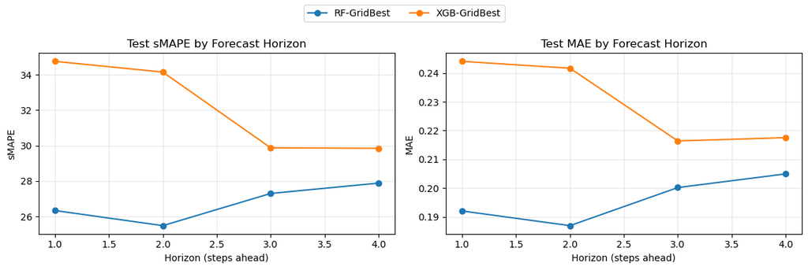

```
Interpretation: largest step-ahead error occurs at h=1 for XGB-GridBest (test sMAPE=34.753).
```

```python
# ============================================================================
# SECTION 5.2: HORIZON-WISE PERFORMANCE PROFILE (H=1..H=4)
# ============================================================================

if 'y_val_multi' not in globals() or 'y_test_multi' not in globals():
    print('Need y_val_multi and y_test_multi. Run Sections 1-4 first.')
else:
    model_preds = {}

    # Prefer grid-best predictions when available.
    if 'rf_val_pred' in globals() and 'rf_test_pred' in globals() and isinstance(rf_val_pred, np.ndarray) and isinstance(rf_test_pred, np.ndarray):
        model_preds['RF-GridBest'] = (rf_val_pred, rf_test_pred)
    elif 'val_pred' in globals() and 'test_pred' in globals() and isinstance(val_pred, np.ndarray) and isinstance(test_pred, np.ndarray):
        model_preds['RF-Multi'] = (val_pred, test_pred)

    if 'xgb_val_best' in globals() and 'xgb_test_best' in globals() and isinstance(xgb_val_best, np.ndarray) and isinstance(xgb_test_best, np.ndarray):
        model_preds['XGB-GridBest'] = (xgb_val_best, xgb_test_best)
    elif 'xgb_val_pred' in globals() and 'xgb_test_pred' in globals() and isinstance(xgb_val_pred, np.ndarray) and isinstance(xgb_test_pred, np.ndarray):
        model_preds['XGB-Multi'] = (xgb_val_pred, xgb_test_pred)

    if len(model_preds) == 0:
        print('No tree prediction arrays found. Run Sections 2-4 first.')
    else:
        max_h = min(4, y_val_multi.shape[1], y_test_multi.shape[1])
        rows = []

        for model_name, (vp, tp) in model_preds.items():
            h_cap = min(max_h, vp.shape[1], tp.shape[1])
            for h in range(h_cap):
                yv = y_val_multi.iloc[:, h].values.astype(float)
                yt = y_test_multi.iloc[:, h].values.astype(float)
                pv = vp[:, h].astype(float)
                pt = tp[:, h].astype(float)

                rows.append({
                    'Model': model_name,
                    'Horizon': h + 1,
                    'sMAPE_val': smape(yv, pv),
                    'sMAPE_test': smape(yt, pt),
                    'MAE_val': mae(yv, pv),
                    'MAE_test': mae(yt, pt),
                    'RMSE_val': rmse(yv, pv),
                    'RMSE_test': rmse(yt, pt),
                })

        horizon_step_metrics = pd.DataFrame(rows)
        horizon_step_metrics = horizon_step_metrics.sort_values(['Model', 'Horizon']).reset_index(drop=True)

        # Degradation relative to each model's h=1 row.
        for metric in ['sMAPE_test', 'MAE_test', 'RMSE_test']:
            base_vals = horizon_step_metrics.groupby('Model')[metric].transform('first')
            horizon_step_metrics[f'{metric}_delta_vs_h1'] = horizon_step_metrics[metric] - base_vals

        # Rounded report view.
        report_cols = [
            'Model', 'Horizon',
            'sMAPE_val', 'sMAPE_test', 'sMAPE_test_delta_vs_h1',
            'MAE_val', 'MAE_test', 'MAE_test_delta_vs_h1',
            'RMSE_val', 'RMSE_test', 'RMSE_test_delta_vs_h1'
        ]
        horizon_step_report = horizon_step_metrics[report_cols].copy()
        num_cols = [c for c in horizon_step_report.columns if c not in ['Model', 'Horizon']]
        for c in num_cols:
            horizon_step_report[c] = horizon_step_report[c].round(4)

        print('Per-horizon performance and degradation (delta vs h=1):')
        display(horizon_step_report)

        # Horizon growth summary via linear slope on test metrics.
        slope_rows = []
        for model_name, g in horizon_step_metrics.groupby('Model'):
            x = g['Horizon'].values.astype(float)
            sm_slope = float(np.polyfit(x, g['sMAPE_test'].values.astype(float), 1)[0]) if len(g) >= 2 else np.nan
            mae_slope = float(np.polyfit(x, g['MAE_test'].values.astype(float), 1)[0]) if len(g) >= 2 else np.nan
            rmse_slope = float(np.polyfit(x, g['RMSE_test'].values.astype(float), 1)[0]) if len(g) >= 2 else np.nan
            slope_rows.append({
                'Model': model_name,
                'Test_sMAPE_Slope_per_Horizon': sm_slope,
                'Test_MAE_Slope_per_Horizon': mae_slope,
                'Test_RMSE_Slope_per_Horizon': rmse_slope,
            })

        horizon_slopes = pd.DataFrame(slope_rows)
        for c in ['Test_sMAPE_Slope_per_Horizon', 'Test_MAE_Slope_per_Horizon', 'Test_RMSE_Slope_per_Horizon']:
            horizon_slopes[c] = horizon_slopes[c].round(4)

        print('Horizon error-growth slopes (test):')
        display(horizon_slopes)

        # Visualization: test sMAPE + MAE by horizon.
        fig, axes = plt.subplots(1, 2, figsize=(12, 4), sharex=True)
        for model_name, g in horizon_step_metrics.groupby('Model'):
            axes[0].plot(g['Horizon'], g['sMAPE_test'], marker='o', label=model_name)
            axes[1].plot(g['Horizon'], g['MAE_test'], marker='o', label=model_name)

        axes[0].set_title('Test sMAPE by Forecast Horizon')
        axes[0].set_xlabel('Horizon (steps ahead)')
        axes[0].set_ylabel('sMAPE')
        axes[0].grid(True, alpha=0.3)

        axes[1].set_title('Test MAE by Forecast Horizon')
        axes[1].set_xlabel('Horizon (steps ahead)')
        axes[1].set_ylabel('MAE')
        axes[1].grid(True, alpha=0.3)

        handles, labels = axes[0].get_legend_handles_labels()
        if len(handles) > 0:
            fig.legend(handles, labels, loc='upper center', ncol=max(1, len(labels)))

        plt.tight_layout(rect=[0, 0, 1, 0.9])
        plt.show()

        # Brief narrative flag.
        worst_row = horizon_step_metrics.sort_values('sMAPE_test', ascending=False).iloc[0]
        print(
            f"Interpretation: largest step-ahead error occurs at h={int(worst_row['Horizon'])} "
            f"for {worst_row['Model']} (test sMAPE={worst_row['sMAPE_test']:.3f})."
        )
```

## 5.3. Forecast-Bias Diagnostics (Over/Under-Forecasting)

Beyond magnitude metrics, this section checks directional bias:

- **MFE (pred - actual)**: positive means over-forecasting, negative means under-forecasting,
- **OverForecastRate** and **UnderForecastRate** across horizons,
- horizon-specific and model-level summaries on validation and test windows.

Interpretation:

- strong non-zero MFE and skewed over/under rates indicate systematic bias,
- this matters even when aggregate sMAPE/MAE are competitive.

```python
# ============================================================================
# SECTION 5.3: FORECAST-BIAS DIAGNOSTICS (DIRECTIONAL)
# ============================================================================

if 'y_val_multi' not in globals() or 'y_test_multi' not in globals():
    print('Need y_val_multi and y_test_multi. Run Sections 1-4 first.')
else:
    model_preds = {}

    if 'rf_val_pred' in globals() and 'rf_test_pred' in globals() and isinstance(rf_val_pred, np.ndarray) and isinstance(rf_test_pred, np.ndarray):
        model_preds['RF-GridBest'] = (rf_val_pred, rf_test_pred)
    elif 'val_pred' in globals() and 'test_pred' in globals() and isinstance(val_pred, np.ndarray) and isinstance(test_pred, np.ndarray):
        model_preds['RF-Multi'] = (val_pred, test_pred)

    if 'xgb_val_best' in globals() and 'xgb_test_best' in globals() and isinstance(xgb_val_best, np.ndarray) and isinstance(xgb_test_best, np.ndarray):
        model_preds['XGB-GridBest'] = (xgb_val_best, xgb_test_best)
    elif 'xgb_val_pred' in globals() and 'xgb_test_pred' in globals() and isinstance(xgb_val_pred, np.ndarray) and isinstance(xgb_test_pred, np.ndarray):
        model_preds['XGB-Multi'] = (xgb_val_pred, xgb_test_pred)

    if len(model_preds) == 0:
        print('No prediction arrays found for bias diagnostics. Run Sections 2-4 first.')
    else:
        rows = []
        for model_name, (vp, tp) in model_preds.items():
            h_cap = min(vp.shape[1], tp.shape[1], y_val_multi.shape[1], y_test_multi.shape[1])

            for h in range(h_cap):
                yv = y_val_multi.iloc[:, h].values.astype(float)
                yt = y_test_multi.iloc[:, h].values.astype(float)
                pv = vp[:, h].astype(float)
                pt = tp[:, h].astype(float)

                err_v = pv - yv
                err_t = pt - yt

                rows.append({
                    'Model': model_name,
                    'Horizon': h + 1,
                    'MFE_val': float(np.mean(err_v)),
                    'OverRate_val': float(np.mean(err_v > 0)),
                    'UnderRate_val': float(np.mean(err_v < 0)),
                    'MFE_test': float(np.mean(err_t)),
                    'OverRate_test': float(np.mean(err_t > 0)),
                    'UnderRate_test': float(np.mean(err_t < 0)),
                })

        bias_horizon = pd.DataFrame(rows)
        for c in ['MFE_val', 'OverRate_val', 'UnderRate_val', 'MFE_test', 'OverRate_test', 'UnderRate_test']:
            bias_horizon[c] = bias_horizon[c].round(4)

        print('Horizon-wise directional bias diagnostics:')
        display(bias_horizon)

        bias_model = bias_horizon.groupby('Model', as_index=False).agg({
            'MFE_val': 'mean',
            'OverRate_val': 'mean',
            'UnderRate_val': 'mean',
            'MFE_test': 'mean',
            'OverRate_test': 'mean',
            'UnderRate_test': 'mean',
        })

        for c in ['MFE_val', 'OverRate_val', 'UnderRate_val', 'MFE_test', 'OverRate_test', 'UnderRate_test']:
            bias_model[c] = bias_model[c].round(4)

        print('Model-level average directional bias across horizons:')
        display(bias_model)

        # Flag likely systematic bias.
        flags = []
        for _, r in bias_model.iterrows():
            if abs(r['MFE_test']) > 0.01 or max(r['OverRate_test'], r['UnderRate_test']) > 0.65:
                flags.append(f"{r['Model']}: systematic test-direction bias likely")
            else:
                flags.append(f"{r['Model']}: test-direction bias relatively balanced")

        print('Bias interpretation flags:')
        for f in flags:
            print(f'- {f}')
```

```
Horizon-wise directional bias diagnostics:
```

|  | Model | Horizon | MFE_val | OverRate_val | UnderRate_val | MFE_test | OverRate_test | UnderRate_test |
| --- | --- | --- | --- | --- | --- | --- | --- | --- |
| 0 | RF-GridBest | 1 | 0.0271 | 1.00 | 0.00 | -0.1921 | 0.0 | 1.0 |
| 1 | RF-GridBest | 2 | 0.0342 | 0.75 | 0.25 | -0.1870 | 0.0 | 1.0 |
| 2 | RF-GridBest | 3 | 0.0117 | 0.50 | 0.50 | -0.2002 | 0.0 | 1.0 |
| 3 | RF-GridBest | 4 | -0.0364 | 0.25 | 0.75 | -0.2049 | 0.0 | 1.0 |
| 4 | XGB-GridBest | 1 | 0.0205 | 0.75 | 0.25 | -0.2440 | 0.0 | 1.0 |
| 5 | XGB-GridBest | 2 | 0.0283 | 0.75 | 0.25 | -0.2416 | 0.0 | 1.0 |
| 6 | XGB-GridBest | 3 | 0.0173 | 0.75 | 0.25 | -0.2164 | 0.0 | 1.0 |
| 7 | XGB-GridBest | 4 | -0.0228 | 0.25 | 0.75 | -0.2175 | 0.0 | 1.0 |

```
Model-level average directional bias across horizons:
```

|  | Model | MFE_val | OverRate_val | UnderRate_val | MFE_test | OverRate_test | UnderRate_test |
| --- | --- | --- | --- | --- | --- | --- | --- |
| 0 | RF-GridBest | 0.0092 | 0.625 | 0.375 | -0.1960 | 0.0 | 1.0 |
| 1 | XGB-GridBest | 0.0108 | 0.625 | 0.375 | -0.2299 | 0.0 | 1.0 |

```
Bias interpretation flags:
- RF-GridBest: systematic test-direction bias likely
- XGB-GridBest: systematic test-direction bias likely
```

## 6. Environment Status

The active `tmu_capstone` environment currently supports full execution of this notebook.

Current status:

- `scikit-learn` imports successfully
- Random Forest sections execute successfully
- XGBoost sections execute successfully

If environment issues reappear on another machine, reinstall key dependencies in the active conda environment and restart the kernel before rerunning the notebook.

## 7. Winner Summary

This section reports:

- best overall model in the combined table
- best rebuilt 02a baseline
- best tree model (`h=1` comparison)

It also quantifies the error gap between best tree and best baseline to support final model-selection interpretation.

```python
# ============================================================================
# SECTION 7: WINNER SUMMARY
# ============================================================================

best_overall = comparison.iloc[0]
best_baseline = comparison[comparison["Family"] == "02a-baseline"].iloc[0]
best_tree = comparison[comparison["Family"] == "tree-h1"].sort_values(["sMAPE_test", "MAE_test", "runtime_sec"]).iloc[0]

print("Best overall model:")
print(
    f"- {best_overall['Model']} | test sMAPE={best_overall['sMAPE_test']:.3f}, "
    f"MAE={best_overall['MAE_test']:.3f}, runtime={best_overall['runtime_sec']:.3f}s"
)

print("\nBest 02a baseline:")
print(
    f"- {best_baseline['Model']} | test sMAPE={best_baseline['sMAPE_test']:.3f}, "
    f"MAE={best_baseline['MAE_test']:.3f}, runtime={best_baseline['runtime_sec']:.3f}s"
)

print("\nBest tree model (one-step / h=1):")
print(
    f"- {best_tree['Model']} | test sMAPE={best_tree['sMAPE_test']:.3f}, "
    f"MAE={best_tree['MAE_test']:.3f}, runtime={best_tree['runtime_sec']:.3f}s"
)

smape_gap = float(best_tree["sMAPE_test"] - best_baseline["sMAPE_test"])
mae_gap = float(best_tree["MAE_test"] - best_baseline["MAE_test"])

print("\nInterpretation:")
if smape_gap < 0:
    print(
        f"- The best tree model beats the strongest baseline by {-smape_gap:.3f} sMAPE and {-mae_gap:.3f} MAE on the test set."
    )
else:
    print(
        f"- The best tree model trails the strongest baseline by {smape_gap:.3f} sMAPE and {mae_gap:.3f} MAE on the test set."
    )

rf_rows = comparison[comparison["Model"].str.contains("RF", case=False, na=False)]
if len(rf_rows) > 0:
    print("- Random Forest is now operational in this environment and included in model/grid sections.")
else:
    print("- Random Forest results are not present; rerun RF sections if needed.")

print("- The comparison table should be treated as the main selection artifact for this notebook.")
```

[output not shown]

## 8. Export Outputs

This section exports all key 02b artifacts to CSV for reporting and cross-notebook comparison:

- tree vs rebuilt 02a baseline comparison table
- tree grid-search results
- tree macro summary table
- XGB per-horizon metrics
- rebuilt 02a baseline table
- tree `h=1` summary table

```python
# ============================================================================
# SECTION 8: EXPORT OUTPUTS
# ============================================================================

export_dir = "../reports/2026-03-26/tables"
os.makedirs(export_dir, exist_ok=True)

if "comparison" in globals() and isinstance(comparison, pd.DataFrame) and not comparison.empty:
    comparison.to_csv(f"{export_dir}/02b_creditreporting_monthly_tree_vs_02a_baselines.csv", index=False)

if "grid_results" in globals() and isinstance(grid_results, pd.DataFrame) and not grid_results.empty:
    grid_results.to_csv(f"{export_dir}/02b_creditreporting_monthly_tree_grid_results.csv", index=False)

if "tree_results" in globals() and isinstance(tree_results, pd.DataFrame) and not tree_results.empty:
    tree_results.to_csv(f"{export_dir}/02b_creditreporting_monthly_tree_model_summary.csv", index=False)

if "xgb_horizon_metrics" in globals() and isinstance(xgb_horizon_metrics, pd.DataFrame) and not xgb_horizon_metrics.empty:
    xgb_horizon_metrics.to_csv(f"{export_dir}/02b_creditreporting_monthly_xgb_horizon_metrics.csv", index=False)

# Export a baseline table cache for backward compatibility with older runs.
if "baseline_results_fast" in globals() and isinstance(baseline_results_fast, pd.DataFrame) and not baseline_results_fast.empty:
    baseline_results_fast.to_csv(f"{export_dir}/02b_creditreporting_monthly_rebuilt_02a_baselines.csv", index=False)
elif "baseline_results" in globals() and isinstance(baseline_results, pd.DataFrame) and not baseline_results.empty:
    baseline_results.to_csv(f"{export_dir}/02b_creditreporting_monthly_rebuilt_02a_baselines.csv", index=False)

if "tree_h1_df" in globals() and isinstance(tree_h1_df, pd.DataFrame) and not tree_h1_df.empty:
    tree_h1_df.to_csv(f"{export_dir}/02b_creditreporting_monthly_tree_h1_summary.csv", index=False)

print(f"Exported available tables to: {export_dir}")
```

```
Exported available tables to: ../reports/2026-03-26/tables
```

## 9. Conclusion

This notebook delivers a leakage-safe tree-model benchmarking workflow aligned with 02a evaluation logic.

Method clarity:

- tree forecasts are generated with a direct multi-horizon design (separate horizon models), not recursive roll-forward.

**Why This Conclusion Is Methodologically Robust (Not Metric-Only):**

- **Validation-size reliability:** Section 4.1 shows RF near-ties on validation (higher tuning uncertainty) and clearer XGB separation
- **Practical + statistical checks:** Section 5.1 quantifies the error gap magnitude and tests RF-vs-XGB difference with paired bootstrap CIs
- **Horizon-step diagnostics:** Section 5.2 shows lead-time-specific behavior instead of relying on a single pooled score
- **Bias diagnostics:** Section 5.3 shows persistent under-forecasting direction (negative MFE and 100% under-forecast rate on this run), confirming systematic miss-patterns beyond average error

**Practical Implications of Forecast Accuracy:**

- Large aggregate error gaps imply materially weaker short-term decision support from current tree specifications versus strong statistical baselines
- Systematic under-forecasting raises operational risk by understating upward complaint-share pressure and delaying response
- Horizon-specific behavior implies model deployment should be lead-time-aware; a single global winner is not always appropriate for all planning horizons

Takeaway:

- tree models provide useful feature diagnostics, but rebuilt 02a statistical baselines remain stronger on this split and under current feature design.

Next steps:

1. add drift-aware features or regime indicators to address level shifts
2. test hybrid baseline-plus-tree correction models
3. evaluate horizon-specific model blending instead of a single winner across all horizons

## 10. Error Analysis (h=1): Residuals and Largest Misses

This section diagnoses one-step forecast errors for RF and XGB.

What to read from outputs:

- residual plots show direction and stability of model bias over time
- largest-miss tables identify specific months/quarters driving headline error
- summary stats (`MAE_h1`, `RMSE_h1`, mean residual) quantify average and tail behavior

Current pattern in this run:

- validation residuals are small and slightly negative (mild overprediction)
- test residuals are largely positive (systematic underprediction in later periods).

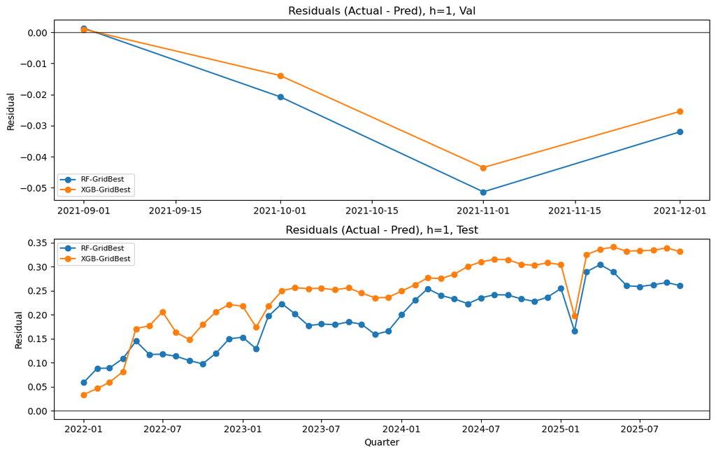

```
Top 3 largest misses per model and split (h=1):
```

|  | Model | Split | Quarter | Actual | Pred | Residual | AbsError |
| --- | --- | --- | --- | --- | --- | --- | --- |
| 0 | RF-GridBest | Test | 2025-03-31 23:59:59.999999999 | 0.892 | 0.587 | 0.304 | 0.304 |
| 1 | RF-GridBest | Test | 2025-02-28 23:59:59.999999999 | 0.876 | 0.587 | 0.290 | 0.290 |
| 2 | RF-GridBest | Test | 2025-04-30 23:59:59.999999999 | 0.896 | 0.607 | 0.289 | 0.289 |
| 3 | RF-GridBest | Val | 2021-10-31 23:59:59.999999999 | 0.603 | 0.655 | -0.051 | 0.051 |
| 4 | RF-GridBest | Val | 2021-11-30 23:59:59.999999999 | 0.613 | 0.645 | -0.032 | 0.032 |
| 5 | RF-GridBest | Val | 2021-09-30 23:59:59.999999999 | 0.624 | 0.645 | -0.021 | 0.021 |
| 6 | XGB-GridBest | Test | 2025-04-30 23:59:59.999999999 | 0.896 | 0.555 | 0.341 | 0.341 |
| 7 | XGB-GridBest | Test | 2025-08-31 23:59:59.999999999 | 0.899 | 0.560 | 0.339 | 0.339 |
| 8 | XGB-GridBest | Test | 2025-03-31 23:59:59.999999999 | 0.892 | 0.555 | 0.336 | 0.336 |
| 9 | XGB-GridBest | Val | 2021-10-31 23:59:59.999999999 | 0.603 | 0.647 | -0.043 | 0.043 |
| 10 | XGB-GridBest | Val | 2021-11-30 23:59:59.999999999 | 0.613 | 0.638 | -0.025 | 0.025 |
| 11 | XGB-GridBest | Val | 2021-09-30 23:59:59.999999999 | 0.624 | 0.638 | -0.014 | 0.014 |

```
Residual summary (h=1):
```

|  | Model | Split | MAE_h1 | RMSE_h1 | MeanResidual |
| --- | --- | --- | --- | --- | --- |
| 0 | RF-GridBest | Test | 0.192 | 0.202 | 0.192 |
| 1 | RF-GridBest | Val | 0.026 | 0.032 | -0.026 |
| 2 | XGB-GridBest | Test | 0.244 | 0.257 | 0.244 |
| 3 | XGB-GridBest | Val | 0.021 | 0.026 | -0.020 |

```python
# ============================================================================
# SECTION 10: ERROR ANALYSIS (H=1) FOR RF AND XGB
# ============================================================================

# Helper to select the best available h=1 predictions from prior sections.
def _pick_h1_predictions(model_prefix):
    if model_prefix == "RF":
        if "rf_val_pred" in globals() and "rf_test_pred" in globals():
            return rf_val_pred[:, 0], rf_test_pred[:, 0], "RF-GridBest"
        if "val_pred" in globals() and "test_pred" in globals():
            return val_pred[:, 0], test_pred[:, 0], "RF-Multi"
        if "rf_best" in globals() and "X_val_scaled" in globals() and "X_test_scaled" in globals():
            _v = rf_best.predict(X_val_scaled)[:, 0]
            _t = rf_best.predict(X_test_scaled)[:, 0]
            return _v, _t, "RF-GridBest (recomputed)"
        if "rf" in globals() and "X_val_scaled" in globals() and "X_test_scaled" in globals():
            _v = rf.predict(X_val_scaled)[:, 0]
            _t = rf.predict(X_test_scaled)[:, 0]
            return _v, _t, "RF-Multi (recomputed)"
        raise RuntimeError("RF predictions/models not found. Rerun Section 2 and/or Section 4.")

    if model_prefix == "XGB":
        if "xgb_val_best" in globals() and "xgb_test_best" in globals():
            return xgb_val_best[:, 0], xgb_test_best[:, 0], "XGB-GridBest"
        if "xgb_val_pred" in globals() and "xgb_test_pred" in globals():
            return xgb_val_pred[:, 0], xgb_test_pred[:, 0], "XGB-Multi"
        if "xgb_best_models" in globals() and "X_val" in globals() and "X_test" in globals() and "predict_xgb_by_horizon" in globals() and "y_train_multi" in globals():
            _v = predict_xgb_by_horizon(xgb_best_models, X_val, y_train_multi.columns)[:, 0]
            _t = predict_xgb_by_horizon(xgb_best_models, X_test, y_train_multi.columns)[:, 0]
            return _v, _t, "XGB-GridBest (recomputed)"
        if "xgb_models" in globals() and "X_val" in globals() and "X_test" in globals() and "predict_xgb_by_horizon" in globals() and "y_train_multi" in globals():
            _v = predict_xgb_by_horizon(xgb_models, X_val, y_train_multi.columns)[:, 0]
            _t = predict_xgb_by_horizon(xgb_models, X_test, y_train_multi.columns)[:, 0]
            return _v, _t, "XGB-Multi (recomputed)"
        raise RuntimeError("XGB predictions/models not found. Rerun Section 3 and/or Section 4.")

    raise ValueError("model_prefix must be RF or XGB")


# Build aligned actual-vs-pred frames for val/test at h=1.
val_index = (y_val_multi.index + 1).to_timestamp(how="end")
test_index = (y_test_multi.index + 1).to_timestamp(how="end")

actual_val = y_val_multi["y_h1"].values
actual_test = y_test_multi["y_h1"].values

rf_val_h1, rf_test_h1, rf_label = _pick_h1_predictions("RF")
xgb_val_h1, xgb_test_h1, xgb_label = _pick_h1_predictions("XGB")

error_rows = []
for split_name, idx, y_true, rf_pred, xgb_pred in [
    ("Val", val_index, actual_val, rf_val_h1, xgb_val_h1),
    ("Test", test_index, actual_test, rf_test_h1, xgb_test_h1),
]:
    for model_name, pred in [(rf_label, rf_pred), (xgb_label, xgb_pred)]:
        resid = y_true - pred
        tmp = pd.DataFrame({
            "Split": split_name,
            "Quarter": idx,
            "Model": model_name,
            "Actual": y_true,
            "Pred": pred,
            "Residual": resid,
            "AbsError": np.abs(resid),
        })
        error_rows.append(tmp)

error_df = pd.concat(error_rows, ignore_index=True)

# Residual plots for h=1 (Val/Test).
fig, axes = plt.subplots(2, 1, figsize=(11, 7), sharex=False)
for ax, split_name in zip(axes, ["Val", "Test"]):
    s = error_df[error_df["Split"] == split_name].copy()
    for model_name in s["Model"].unique():
        ms = s[s["Model"] == model_name]
        ax.plot(ms["Quarter"], ms["Residual"], marker="o", label=model_name)
    ax.axhline(0.0, color="black", linewidth=1, alpha=0.7)
    ax.set_title(f"Residuals (Actual - Pred), h=1, {split_name}")
    ax.set_ylabel("Residual")
    ax.legend(fontsize=8)

axes[-1].set_xlabel("Quarter")
plt.tight_layout()
plt.show()

# Largest misses by absolute error.
top_misses = (
    error_df.sort_values(["Model", "Split", "AbsError"], ascending=[True, True, False])
            .groupby(["Model", "Split"], as_index=False)
            .head(3)
            .reset_index(drop=True)
)

for c in ["Actual", "Pred", "Residual", "AbsError"]:
    top_misses[c] = top_misses[c].round(3)

print("Top 3 largest misses per model and split (h=1):")
display(top_misses[["Model", "Split", "Quarter", "Actual", "Pred", "Residual", "AbsError"]])

# Compact summary stats for quick comparison.
error_summary = (
    error_df.groupby(["Model", "Split"], as_index=False)
            .agg(
                MAE_h1=("AbsError", "mean"),
                RMSE_h1=("Residual", lambda s: float(np.sqrt(np.mean(np.square(s))))),
                MeanResidual=("Residual", "mean"),
            )
)
for c in ["MAE_h1", "RMSE_h1", "MeanResidual"]:
    error_summary[c] = error_summary[c].round(3)

print("Residual summary (h=1):")
display(error_summary)
```